# Estatística descritiva univariada

Processo (dentro exploração dos dados) em que se analisa apenas uma variável.

Conceitos importantes para geração de features (engineering), por exemplo, que categorizar uma coluna contínua ("acima média", "abaixo média", ...)

### Percentis

- divide os dados em **100 partes do todo**
- 1% em cada segmento
- mediana, por exemplo, é percentil 50% (divide os dados na metade)

### Quartis

- divide os dados em 4 conjuntos
- 25% em cada conjunto
- Q2 é a mediana

### Amplitude interquartil

- diferença entre 3th e 1rs quartis (Q3 - Q1)
- diz quão esparso é aquela variável
- quanto mais estreito, mais concentrado são os dados em torno da média

### Assimetria (*skewness*)

- grau de distorção da curva simétrica a distribuição normal
- mede a falta de simetria na distribuição dos dados
- diferencia valores extremos em uma cauda comparado na outra
- distruição simétria ("*normal convencional*") possui assimetria 0

[figure not shown]

### Curtose (*kurtosis*)

- medida de dispersão que caracteriza o "achatamento" da curva da função de distribuição
- são comparações a distribuição normal
- **mesócurtica(0):**
  - curva normal
- **leptocúrtica(> 0):**
  - possui a curva da função de distribuição mais afunilada
  - pico mais alto do que a distribuição normal
  - possui caudas pesadas
- **platicúrtica(< 0):**
  - função de distribuição é mais achatada do que a distribuição normal

[figure not shown]

# Estatística descritiva bivariada/multivariada

- amostra possui mais de uma variável
- relacionamento entre os pares ou conjunto de variáveis
  - tabulações cruzadas e tabelas de contingência
  - representação gráfica via gráfico de dispersão
  - as medidas quantitativas de dependência
  - as descrições de distribuição condicionais

### Correlação

- medida padronizada da relação entre duas variáveis
- indica a força e a direção do relacionamento de duas variáveis aleatória

**Correlação varia de -1 a 1**

- próxima de zero: não estão relacionadas
- próxima de -1: movem-se em direções opostas
- próxima de 1: movem-se juntas

[figure not shown]

#### Correlação de Spearman

Avalia a relação **monotônica** entre duas variáveis contínuas ou ordinais (1,2,3,...) .

Relação monotônicas variáveis:

- mudar juntas mas não necessariamente a uma taxa constante
- o coeficiente de correlação de Spearman se baseia nos valores classificados de cada variável (elabora um "ranking"), em vez de dados brutos, tornando-a menos sensível a outliers.

[figure not shown]

#### Correlação de Pearson

Relação linear entre duas variáveis contínuas:

- mudança em uma variável é associada a uma mudança proporcional na outra variável

# Normalizar e Padronizar

- deixar todas as variáveis na mesma ordem de grandeza
- **PADRONIZAR:** deixar **média=0** e **desvioPadrao=1**
- **NORMALIZAR:** deixar no **intervalo de 0 a 1**, **variavel=[0,1]** com resultado **positivo**; caso tenha resultado **negativo** então **variavel=[-1, 1]**

# Aceleradev Codenation - Semana 3

Dados de casa brasileiras.

dados : https://www.kaggle.com/rubenssjr/brasilian-houses-to-rent

Colunas

- city : Cidade onde o imóvel está localizada / City where the property is located
- area : Area do imovel / Property area
- rooms: Numero de quartos/ Quantity of rooms
- bathroom: Numero de banheiros / Quantity of bathroom
- parking spaces : Numero de vagas / Quantity of parking spaces
- floor : Andar / Floor
- animal : Aceita animais? / Acept animals?
- furniture : Mobilhada? / Furniture?
- hoa (RS): Valor do condomínio / Homeowners association tax
- rent amount (RS) : Valor do Aluguel (/) Rent amount
- property tax (RS) : IPTU (/) Property tax
- fire insurance (RS) : Seguro Incendio / Fire Insurance
- total (RS) : Valor total / Total

### Importando os pacotes

```python
import pandas as pd
import funcoesProprias as md
```

```python
md.configuraJupyter()
```

```python
df = pd.read_csv('houses_to_rent_v2.csv')
```

```python
df.head(5)
```

|  | city | area | rooms | bathroom | parking spaces | floor | animal | furniture | hoa (R$) | rent amount (R$) | property tax (R$) | fire insurance (R$) | total (R$) |
| --- | --- | --- | --- | --- | --- | --- | --- | --- | --- | --- | --- | --- | --- |
| 0 | São Paulo | 70 | 2 | 1 | 1 | 7 | acept | furnished | 2065 | 3300 | 211 | 42 | 5618 |
| 1 | São Paulo | 320 | 4 | 4 | 0 | 20 | acept | not furnished | 1200 | 4960 | 1750 | 63 | 7973 |
| 2 | Porto Alegre | 80 | 1 | 1 | 1 | 6 | acept | not furnished | 1000 | 2800 | 0 | 41 | 3841 |
| 3 | Porto Alegre | 51 | 2 | 1 | 0 | 2 | acept | not furnished | 270 | 1112 | 22 | 17 | 1421 |
| 4 | São Paulo | 25 | 1 | 1 | 0 | 1 | not acept | not furnished | 0 | 800 | 25 | 11 | 836 |

```python
df.dtypes
```

```
city                   object
area                    int64
rooms                   int64
bathroom                int64
parking spaces          int64
floor                  object
animal                 object
furniture              object
hoa (R$)                int64
rent amount (R$)        int64
property tax (R$)       int64
fire insurance (R$)     int64
total (R$)              int64
dtype: object
```

```python
df.info()
```

```
<class 'pandas.core.frame.DataFrame'>
RangeIndex: 10692 entries, 0 to 10691
Data columns (total 13 columns):
 #   Column               Non-Null Count  Dtype
---  ------               --------------  -----
 0   city                 10692 non-null  object
 1   area                 10692 non-null  int64
 2   rooms                10692 non-null  int64
 3   bathroom             10692 non-null  int64
 4   parking spaces       10692 non-null  int64
 5   floor                10692 non-null  object
 6   animal               10692 non-null  object
 7   furniture            10692 non-null  object
 8   hoa (R$)             10692 non-null  int64
 9   rent amount (R$)     10692 non-null  int64
 10  property tax (R$)    10692 non-null  int64
 11  fire insurance (R$)  10692 non-null  int64
 12  total (R$)           10692 non-null  int64
dtypes: int64(9), object(4)
memory usage: 1.1+ MB
```

```python
df.shape
```

```
(10692, 13)
```

```python
md.dfExploracao(df)
```

|  | colunas | tipos | na_perct | quantUnicos |
| --- | --- | --- | --- | --- |
| 0 | city | object | 0.0 | 5 |
| 1 | area | int64 | 0.0 | 517 |
| 2 | rooms | int64 | 0.0 | 11 |
| 3 | bathroom | int64 | 0.0 | 10 |
| 4 | parking spaces | int64 | 0.0 | 11 |
| 5 | floor | object | 0.0 | 35 |
| 6 | animal | object | 0.0 | 2 |
| 7 | furniture | object | 0.0 | 2 |
| 8 | hoa (R$) | int64 | 0.0 | 1679 |
| 9 | rent amount (R$) | int64 | 0.0 | 1195 |
| 10 | property tax (R$) | int64 | 0.0 | 1243 |
| 11 | fire insurance (R$) | int64 | 0.0 | 216 |
| 12 | total (R$) | int64 | 0.0 | 5751 |

# Problema : Explorar o valor do aluguel (rent amount RS)

## Estatística univariada

```python
df.rename(columns = {'rent amount (R$)' : 'valor_aluguel'}, inplace = True)
```

```python
df.head()
```

|  | city | area | rooms | bathroom | parking spaces | floor | animal | furniture | hoa (R$) | valor_aluguel | property tax (R$) | fire insurance (R$) | total (R$) |
| --- | --- | --- | --- | --- | --- | --- | --- | --- | --- | --- | --- | --- | --- |
| 0 | São Paulo | 70 | 2 | 1 | 1 | 7 | acept | furnished | 2065 | 3300 | 211 | 42 | 5618 |
| 1 | São Paulo | 320 | 4 | 4 | 0 | 20 | acept | not furnished | 1200 | 4960 | 1750 | 63 | 7973 |
| 2 | Porto Alegre | 80 | 1 | 1 | 1 | 6 | acept | not furnished | 1000 | 2800 | 0 | 41 | 3841 |
| 3 | Porto Alegre | 51 | 2 | 1 | 0 | 2 | acept | not furnished | 270 | 1112 | 22 | 17 | 1421 |
| 4 | São Paulo | 25 | 1 | 1 | 0 | 1 | not acept | not furnished | 0 | 800 | 25 | 11 | 836 |

```python
df['valor_aluguel'].mean()
```

```
3896.247194163861
```

```python
df['valor_aluguel'].median()
```

```
2661.0
```

**OBS:** quando a **MÉDIA** muito mais alta que a **MEDIANA** é indício de **OUTLIERS**.

```python
df['valor_aluguel'].std()
```

```
3408.5455176710675
```

**Desvio padrão** ALTO (próximo a média) indica **dados esparsos**, ou seja, tenho bastante valores altos e valores baixos. Requer uma análise mais minuciosa.

```python
df['valor_aluguel'].describe()
```

```
count    10692.000000
mean      3896.247194
std       3408.545518
min        450.000000
25%       1530.000000
50%       2661.000000
75%       5000.000000
max      45000.000000
Name: valor_aluguel, dtype: float64
```

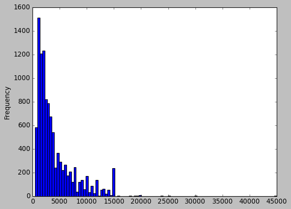

```python
df['valor_aluguel'].plot(kind = 'hist', bins= 100)
```

```python
# quantidade de observações acima do Q3
df.shape[0] * .25
```

```
2673.0
```

```python
# calcula skewness
# skewness positive skew
df.valor_aluguel.skew()
```

```
1.8388773035440982
```

```python
# calcula kurtose
# kurtose - leptocurtica
df.valor_aluguel.kurtosis()
```

```
4.624228179818687
```

## Exploracao multivariáveis

### Perguntas

- Qual a cidade com a média de aluguel mais cara?
- Quantos banheiros existem nas residencias com alugueis mais altos?
- Os imóveis mais caros aceitam animal?
- Os imóveis mais caros são mobiliados?

```python
#Qual a cidade com a média de aluguel mais alta?
df.groupby('city')['valor_aluguel'].median().reset_index().sort_values('valor_aluguel', ascending = False)
```

|  | city | valor_aluguel |
| --- | --- | --- |
| 4 | São Paulo | 3400 |
| 0 | Belo Horizonte | 2300 |
| 3 | Rio de Janeiro | 2300 |
| 2 | Porto Alegre | 1650 |
| 1 | Campinas | 1500 |

```python
df['valor_aluguel'].describe()
```

```
count    10692.000000
mean      3896.247194
std       3408.545518
min        450.000000
25%       1530.000000
50%       2661.000000
75%       5000.000000
max      45000.000000
Name: valor_aluguel, dtype: float64
```

```python
#Quantos banheiros existem em média nas residencias com alugueis mais altos?
## definicao: algueis mais altos são valores acima de 5000 (quartil Q3)
df['aluguel_alto'] = ['Alto' if x > 5000 else 'Baixo' for x in df['valor_aluguel']]
```

```python
df.groupby('aluguel_alto')['bathroom'].mean()
```

```
aluguel_alto
Alto     3.729027
Baixo    1.772108
Name: bathroom, dtype: float64
```

### Hipóteses

- São Paulo é a cidade com o aluguel mais caro.
- Quanto mais banheiros em um imovel maior o valor do aluguel.
- Os imoveis com mobilia tem o aluguel mais alto.

```python
df[['valor_aluguel', 'bathroom']].corr(method = 'spearman')
```

|  | valor_aluguel | bathroom |
| --- | --- | --- |
| valor_aluguel | 1.00000 | 0.71589 |
| bathroom | 0.71589 | 1.00000 |

```python
aux = pd.DataFrame({'colunas' : df.columns, 'tipos' : df.dtypes})
```

```python
lista = list(aux[aux['tipos'] == 'int64']['colunas'])
```

```python
for coluna in lista:
    print(coluna)
    print(df[['valor_aluguel', coluna]].corr(method = 'spearman'))
```

```
area
               valor_aluguel      area
valor_aluguel       1.000000  0.728095
area                0.728095  1.000000
rooms
               valor_aluguel     rooms
valor_aluguel       1.000000  0.600969
rooms               0.600969  1.000000
bathroom
               valor_aluguel  bathroom
valor_aluguel        1.00000   0.71589
bathroom             0.71589   1.00000
parking spaces
                valor_aluguel  parking spaces
valor_aluguel        1.000000        0.620175
parking spaces       0.620175        1.000000
hoa (R$)
               valor_aluguel  hoa (R$)
valor_aluguel       1.000000  0.355785
hoa (R$)            0.355785  1.000000
valor_aluguel
               valor_aluguel  valor_aluguel
valor_aluguel            1.0            1.0
valor_aluguel            1.0            1.0
property tax (R$)
                   valor_aluguel  property tax (R$)
valor_aluguel            1.00000            0.65923
property tax (R$)        0.65923            1.00000
fire insurance (R$)
                     valor_aluguel  fire insurance (R$)
valor_aluguel             1.000000             0.988045
fire insurance (R$)       0.988045             1.000000
total (R$)
               valor_aluguel  total (R$)
valor_aluguel       1.000000    0.968176
total (R$)          0.968176    1.000000
```

```python
df[lista].corr(method='spearman')
```

|  | area | rooms | bathroom | parking spaces | hoa (R$) | valor_aluguel | property tax (R$) | fire insurance (R$) | total (R$) |
| --- | --- | --- | --- | --- | --- | --- | --- | --- | --- |
| area | 1.000000 | 0.848880 | 0.827743 | 0.701161 | 0.225983 | 0.728095 | 0.682270 | 0.745816 | 0.742642 |
| rooms | 0.848880 | 1.000000 | 0.769822 | 0.646679 | 0.206182 | 0.600969 | 0.595516 | 0.613788 | 0.621837 |
| bathroom | 0.827743 | 0.769822 | 1.000000 | 0.702826 | 0.293821 | 0.715890 | 0.654556 | 0.721150 | 0.740281 |
| parking spaces | 0.701161 | 0.646679 | 0.702826 | 1.000000 | 0.229139 | 0.620175 | 0.582921 | 0.625150 | 0.641078 |
| hoa (R$) | 0.225983 | 0.206182 | 0.293821 | 0.229139 | 1.000000 | 0.355785 | 0.392537 | 0.293228 | 0.519755 |
| valor_aluguel | 0.728095 | 0.600969 | 0.715890 | 0.620175 | 0.355785 | 1.000000 | 0.659230 | 0.988045 | 0.968176 |
| property tax (R$) | 0.682270 | 0.595516 | 0.654556 | 0.582921 | 0.392537 | 0.659230 | 1.000000 | 0.656049 | 0.731439 |
| fire insurance (R$) | 0.745816 | 0.613788 | 0.721150 | 0.625150 | 0.293228 | 0.988045 | 0.656049 | 1.000000 | 0.945772 |
| total (R$) | 0.742642 | 0.621837 | 0.740281 | 0.641078 | 0.519755 | 0.968176 | 0.731439 | 0.945772 | 1.000000 |

# Visualização de dados

## Tipos

- histograma
- boxplot
- dispersão (gráfico de pontos)
- matriz de correlação

## Boxplot interpretação

[figure not shown]

```python
# bibliotecas de visualização
import matplotlib.pyplot as plt
import seaborn as sns
```

```python
df.head()
```

|  | city | area | rooms | bathroom | parking spaces | floor | animal | furniture | hoa (R$) | valor_aluguel | property tax (R$) | fire insurance (R$) | total (R$) | aluguel_alto |
| --- | --- | --- | --- | --- | --- | --- | --- | --- | --- | --- | --- | --- | --- | --- |
| 0 | São Paulo | 70 | 2 | 1 | 1 | 7 | acept | furnished | 2065 | 3300 | 211 | 42 | 5618 | Baixo |
| 1 | São Paulo | 320 | 4 | 4 | 0 | 20 | acept | not furnished | 1200 | 4960 | 1750 | 63 | 7973 | Baixo |
| 2 | Porto Alegre | 80 | 1 | 1 | 1 | 6 | acept | not furnished | 1000 | 2800 | 0 | 41 | 3841 | Baixo |
| 3 | Porto Alegre | 51 | 2 | 1 | 0 | 2 | acept | not furnished | 270 | 1112 | 22 | 17 | 1421 | Baixo |
| 4 | São Paulo | 25 | 1 | 1 | 0 | 1 | not acept | not furnished | 0 | 800 | 25 | 11 | 836 | Baixo |

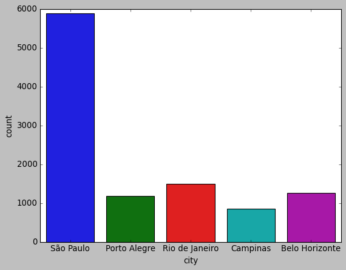

```python
# contagem dos valores
sns.countplot(x = 'city', data = df)
```

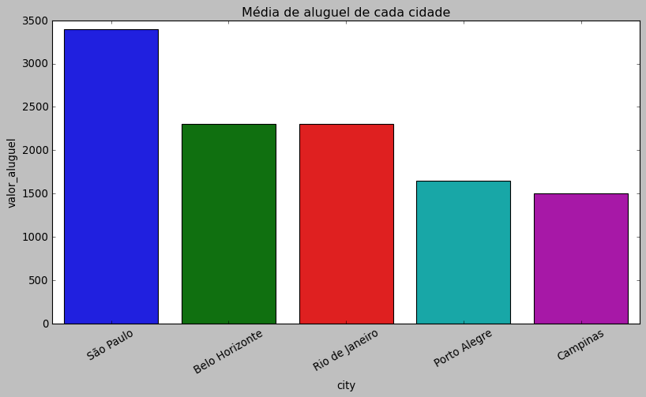

```python
# mexendo tamanho da imagem
plt.figure(figsize = (12,6))
# plotar a media de aluguel por cidade
aux = df.groupby('city')['valor_aluguel'].median().reset_index().sort_values('valor_aluguel', ascending = False)
# vosilizando barras
sns.barplot(x = 'city', y = 'valor_aluguel', data = aux)
# titulo
plt.title('Média de aluguel de cada cidade')
# não mostrar descrição do objeto
plt.xticks(rotation = 30)
plt.show()
```

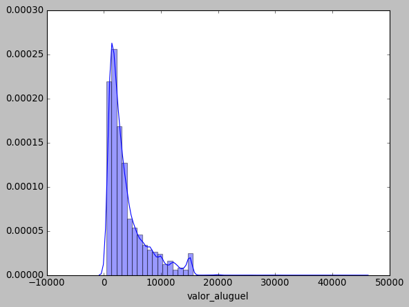

```python
# histograma
sns.distplot(df['valor_aluguel'])
```

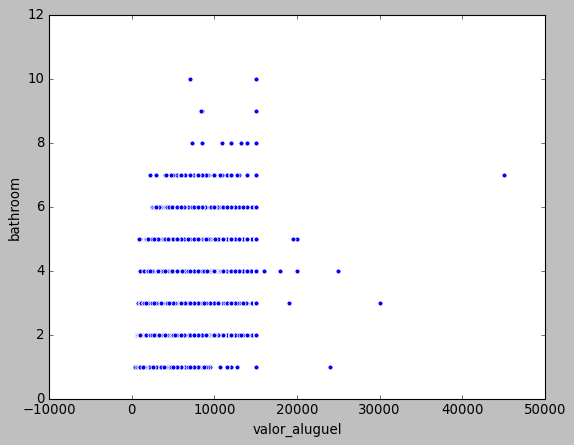

```python
# dispersao - grafico de pontos
sns.scatterplot(x = 'valor_aluguel', y = 'bathroom', data = df)
```

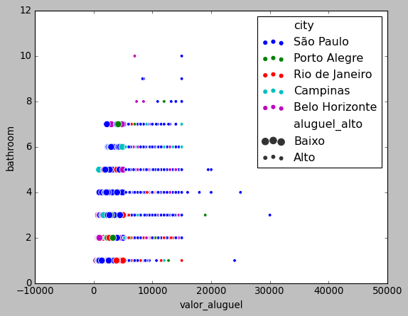

```python
# dispersao - grafico de pontos
# pintando cores
sns.scatterplot(x='valor_aluguel', y='bathroom', hue='city', size='aluguel_alto', data = df)
```

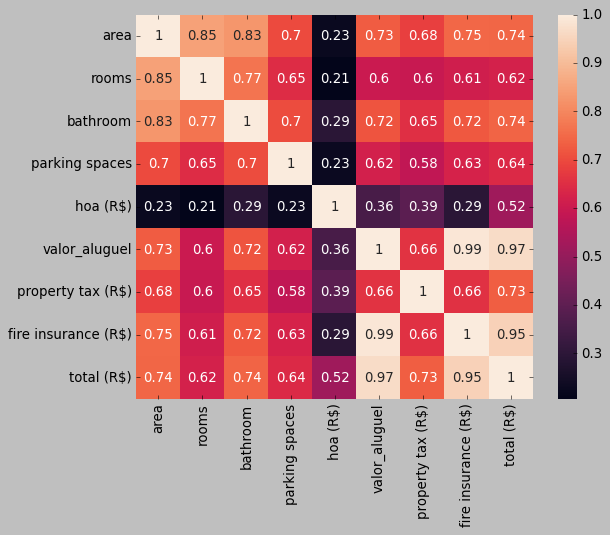

```python
# matriz de correlação
sns.heatmap(df.corr(method = 'spearman'), annot=True)
```

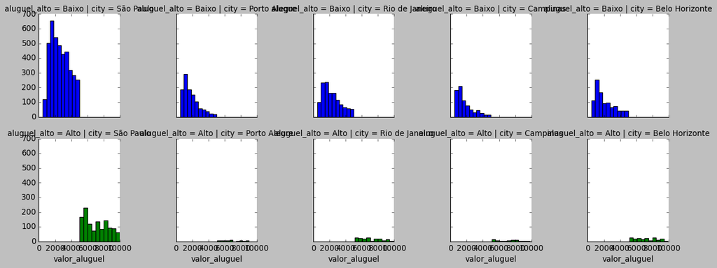

```python
# facetando o grafico

# filtro pra melhorar o gráfico
filtro = df['valor_aluguel'] < 10000
g = sns.FacetGrid(df[filtro], col='city', row='aluguel_alto', hue='aluguel_alto')
g = g.map(plt.hist, 'valor_aluguel')
```

# Conteúdo Extra

```python
explora = md.dfExploracao(df)
```

```python
explora.sort_values('tipos', ascending=True)
```

|  | colunas | tipos | na_perct | quantUnicos |
| --- | --- | --- | --- | --- |
| 1 | area | int64 | 0.0 | 517 |
| 2 | rooms | int64 | 0.0 | 11 |
| 3 | bathroom | int64 | 0.0 | 10 |
| 4 | parking spaces | int64 | 0.0 | 11 |
| 8 | hoa (R$) | int64 | 0.0 | 1679 |
| 9 | valor_aluguel | int64 | 0.0 | 1195 |
| 10 | property tax (R$) | int64 | 0.0 | 1243 |
| 11 | fire insurance (R$) | int64 | 0.0 | 216 |
| 12 | total (R$) | int64 | 0.0 | 5751 |
| 0 | city | object | 0.0 | 5 |
| 5 | floor | object | 0.0 | 35 |
| 6 | animal | object | 0.0 | 2 |
| 7 | furniture | object | 0.0 | 2 |
| 13 | aluguel_alto | object | 0.0 | 2 |

```python
colsNum = explora['tipos'] != 'object'
colsNum = explora[colsNum].colunas
```

```python
df[colsNum]
```

|  | area | rooms | bathroom | parking spaces | hoa (R$) | valor_aluguel | property tax (R$) | fire insurance (R$) | total (R$) |
| --- | --- | --- | --- | --- | --- | --- | --- | --- | --- |
| 0 | 70 | 2 | 1 | 1 | 2065 | 3300 | 211 | 42 | 5618 |
| 1 | 320 | 4 | 4 | 0 | 1200 | 4960 | 1750 | 63 | 7973 |
| 2 | 80 | 1 | 1 | 1 | 1000 | 2800 | 0 | 41 | 3841 |
| 3 | 51 | 2 | 1 | 0 | 270 | 1112 | 22 | 17 | 1421 |
| 4 | 25 | 1 | 1 | 0 | 0 | 800 | 25 | 11 | 836 |
| ... | ... | ... | ... | ... | ... | ... | ... | ... | ... |
| 10687 | 63 | 2 | 1 | 1 | 402 | 1478 | 24 | 22 | 1926 |
| 10688 | 285 | 4 | 4 | 4 | 3100 | 15000 | 973 | 191 | 19260 |
| 10689 | 70 | 3 | 3 | 0 | 980 | 6000 | 332 | 78 | 7390 |
| 10690 | 120 | 2 | 2 | 2 | 1585 | 12000 | 279 | 155 | 14020 |
| 10691 | 80 | 2 | 1 | 0 | 0 | 1400 | 165 | 22 | 1587 |

10692 rows × 9 columns

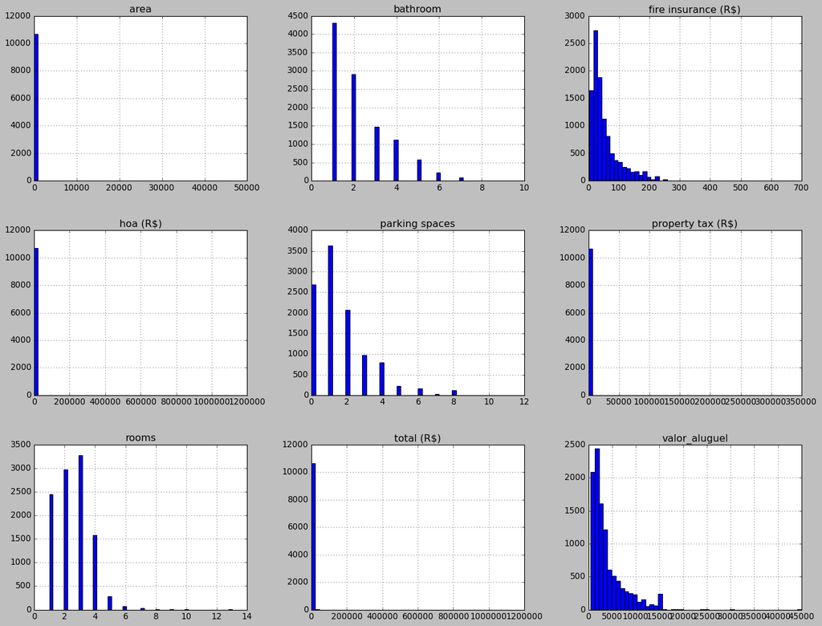

```python
df[colsNum].hist(bins = 50, figsize=(20,15))
#save_fig("attribute_histogram_plots")
plt.show()
```

```python
df[colsNum].describe()
```

|  | area | rooms | bathroom | parking spaces | hoa (R$) | valor_aluguel | property tax (R$) | fire insurance (R$) | total (R$) |
| --- | --- | --- | --- | --- | --- | --- | --- | --- | --- |
| count | 10692.000000 | 10692.000000 | 10692.000000 | 10692.000000 | 1.069200e+04 | 10692.000000 | 10692.000000 | 10692.000000 | 1.069200e+04 |
| mean | 149.217920 | 2.506079 | 2.236813 | 1.609147 | 1.174022e+03 | 3896.247194 | 366.704358 | 53.300879 | 5.490487e+03 |
| std | 537.016942 | 1.171266 | 1.407198 | 1.589521 | 1.559231e+04 | 3408.545518 | 3107.832321 | 47.768031 | 1.648473e+04 |
| min | 11.000000 | 1.000000 | 1.000000 | 0.000000 | 0.000000e+00 | 450.000000 | 0.000000 | 3.000000 | 4.990000e+02 |
| 25% | 56.000000 | 2.000000 | 1.000000 | 0.000000 | 1.700000e+02 | 1530.000000 | 38.000000 | 21.000000 | 2.061750e+03 |
| 50% | 90.000000 | 2.000000 | 2.000000 | 1.000000 | 5.600000e+02 | 2661.000000 | 125.000000 | 36.000000 | 3.581500e+03 |
| 75% | 182.000000 | 3.000000 | 3.000000 | 2.000000 | 1.237500e+03 | 5000.000000 | 375.000000 | 68.000000 | 6.768000e+03 |
| max | 46335.000000 | 13.000000 | 10.000000 | 12.000000 | 1.117000e+06 | 45000.000000 | 313700.000000 | 677.000000 | 1.120000e+06 |

```python
aux = df[colsNum]
filtro = (aux['total (R$)'] < 10e3) & (aux['area'] < 10e3)
aux[filtro].describe()
```

|  | area | rooms | bathroom | parking spaces | hoa (R$) | valor_aluguel | property tax (R$) | fire insurance (R$) | total (R$) |
| --- | --- | --- | --- | --- | --- | --- | --- | --- | --- |
| count | 9202.000000 | 9202.000000 | 9202.000000 | 9202.000000 | 9202.000000 | 9202.000000 | 9202.000000 | 9202.000000 | 9202.000000 |
| mean | 112.650076 | 2.322647 | 1.938492 | 1.325364 | 685.148663 | 2798.475549 | 196.069333 | 38.410454 | 3718.243860 |
| std | 100.183647 | 1.087272 | 1.165343 | 1.358068 | 704.866307 | 1787.260896 | 287.137670 | 25.849658 | 2290.387227 |
| min | 11.000000 | 1.000000 | 1.000000 | 0.000000 | 0.000000 | 450.000000 | 0.000000 | 3.000000 | 499.000000 |
| 25% | 52.000000 | 1.000000 | 1.000000 | 0.000000 | 170.000000 | 1400.000000 | 30.000000 | 19.000000 | 1909.000000 |
| 50% | 80.000000 | 2.000000 | 2.000000 | 1.000000 | 500.000000 | 2300.000000 | 100.000000 | 31.000000 | 3065.500000 |
| 75% | 140.000000 | 3.000000 | 2.000000 | 2.000000 | 975.000000 | 3700.000000 | 250.000000 | 51.000000 | 5024.000000 |
| max | 2000.000000 | 10.000000 | 10.000000 | 10.000000 | 4900.000000 | 9800.000000 | 4247.000000 | 160.000000 | 9998.000000 |

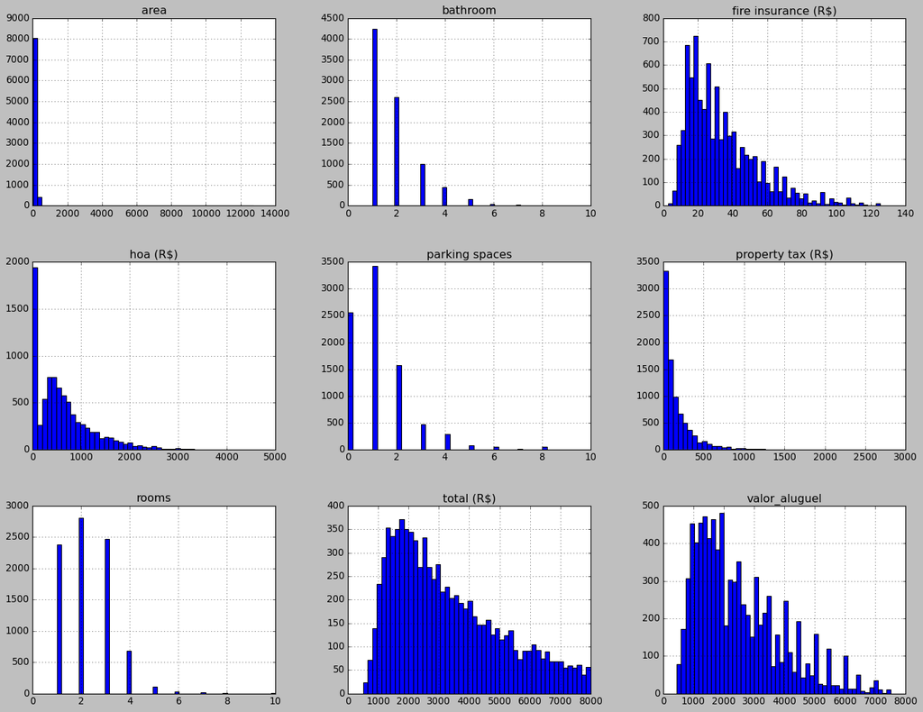

```python
# quant linhas descartadas
filtro = (aux['total (R$)'] < 8e3)
aux[filtro].hist(bins = 50, figsize=(20,15))
#save_fig("attribute_histogram_plots")
plt.show()
```

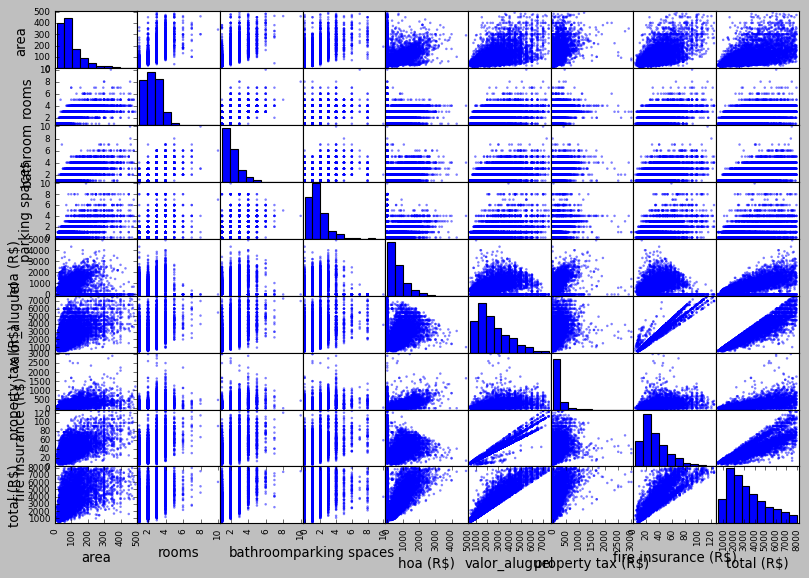

```python
filtro = (aux['total (R$)'] < 8e3)
filtro2 = filtro & (aux['area'] < 500)
pd.plotting.scatter_matrix(aux[filtro2],figsize=(12,8))
plt.show()
```

```python
def plotNumVsNum(df, tamanho=1):
    # plota todas colunas Numericas X todas colunas Numericas
    # matriz de dispersao (pontos)
    import matplotlib.pyplot as plt
    from pandas.plotting import scatter_matrix

    scatter_matrix(df, figsize=(12*tamanho,8*tamanho))

    print("TODAS COLUNAS NUMÉRICAS")
    plt.show()
```

```python
colsNum
```

```
1                    area
2                   rooms
3                bathroom
4          parking spaces
8                hoa (R$)
9           valor_aluguel
10      property tax (R$)
11    fire insurance (R$)
12             total (R$)
Name: colunas, dtype: object
```

```
TODAS COLUNAS NUMÉRICAS
```

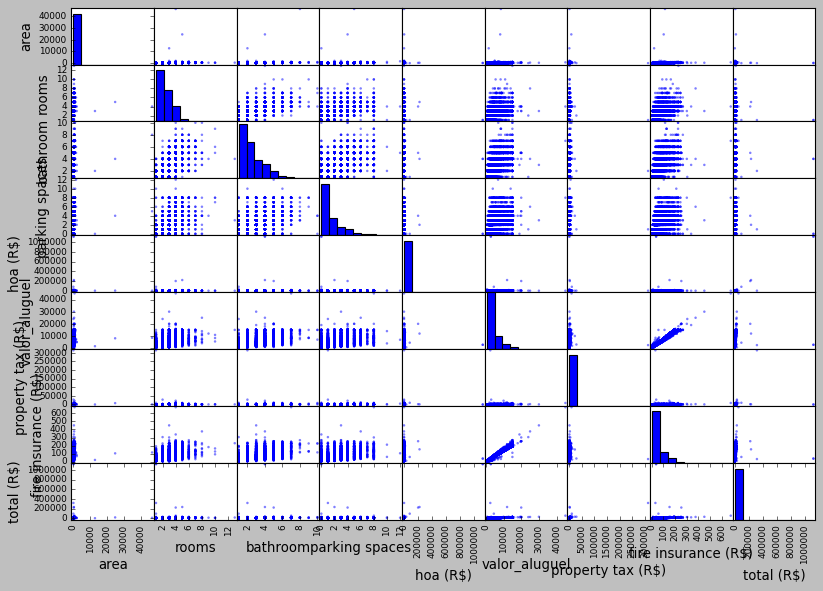

```python
md.plotNumVsNum(df[colsNum])
```

### ATENÇÃO

Ainda seria necessário visualizar as colunas tipo **object**.

Fazer uma ocntagem de barras delas.

```python
colsObj = explora[explora.tipos == 'object'].colunas
```

```python
aux = df[colsObj]
#aux.drop('floor', axis=1, inplace=True)
```

```python
aux
```

|  | city | floor | animal | furniture | aluguel_alto |
| --- | --- | --- | --- | --- | --- |
| 0 | São Paulo | 7 | acept | furnished | Baixo |
| 1 | São Paulo | 20 | acept | not furnished | Baixo |
| 2 | Porto Alegre | 6 | acept | not furnished | Baixo |
| 3 | Porto Alegre | 2 | acept | not furnished | Baixo |
| 4 | São Paulo | 1 | not acept | not furnished | Baixo |
| ... | ... | ... | ... | ... | ... |
| 10687 | Porto Alegre | 5 | not acept | furnished | Baixo |
| 10688 | São Paulo | 17 | acept | not furnished | Alto |
| 10689 | Rio de Janeiro | 8 | not acept | furnished | Alto |
| 10690 | Rio de Janeiro | 8 | acept | furnished | Alto |
| 10691 | São Paulo | - | acept | not furnished | Baixo |

10692 rows × 5 columns

```python
def plotObjCols(df, numColsJuntas=2, tamanho=1):
    # recebe DF apenas com colunas de caracteres
    # e faz CONTAGEM em graficos de BARRA de CADA COLUNA
    # numColsJuntas= quant colunas , tamanho= [-10,10]
    # nada retorna, apenas plota
    import matplotlib.pyplot as plt
    from seaborn import countplot

    colunas = df.columns
    i = 0

    while i <= len(colunas):
        #plotaCont2em2(aux.iloc[:, i:i+numColsJuntas], )

        # selecioando colunas
        aux = df.iloc[:, i:i+numColsJuntas]
        # ajusta subplots
        fig, ax = plt.subplots(1, numColsJuntas, figsize=(12*tamanho,5*tamanho))

        # faz plots
        for j, nomeCol in enumerate(aux.columns):
            countplot(aux[nomeCol], ax=ax[j])
            plt.xticks(rotation = 30)
        # tira descricao
        fig.show()
        # incrementa
        i += numColsJuntas

    print('CONTAGEM DAS COLUNAS OBJECT')
    plt.show()
```

```
CONTAGEM DAS COLUNAS OBJECT
```

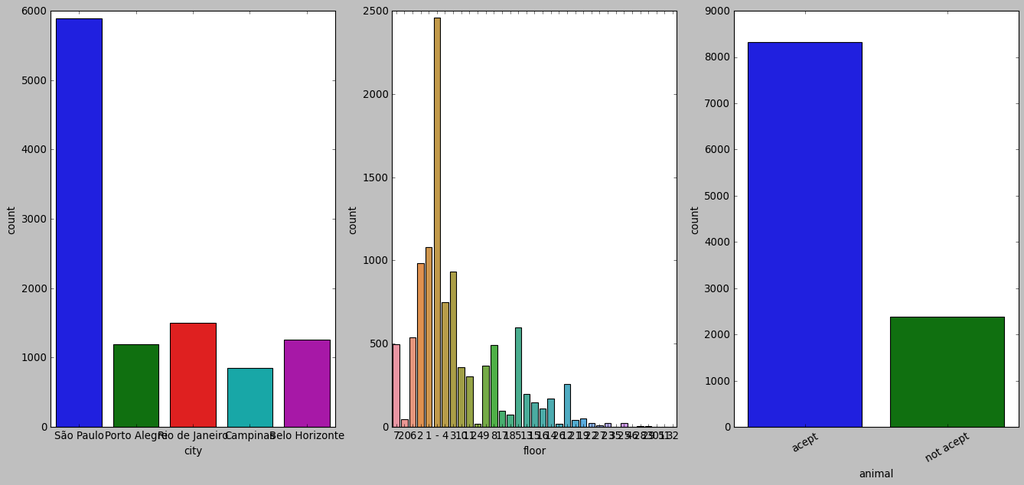

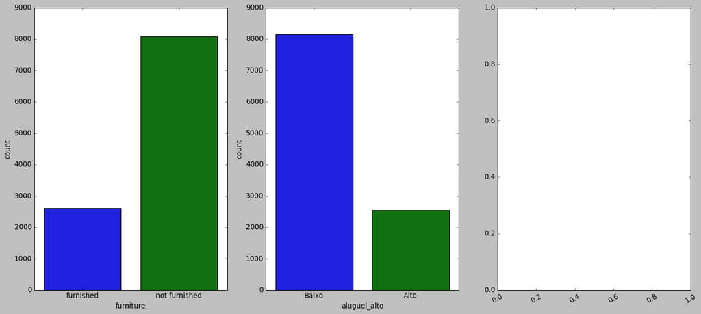

```python
md.plotObjCols(aux, numColsJuntas=3, tamanho=1.7)
```

```
CONTAGEM DAS COLUNAS OBJECT
```

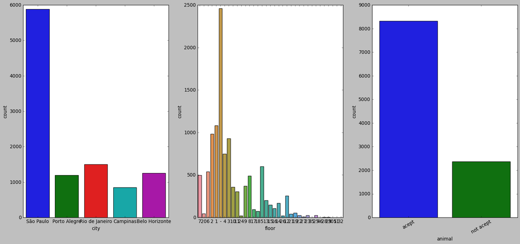

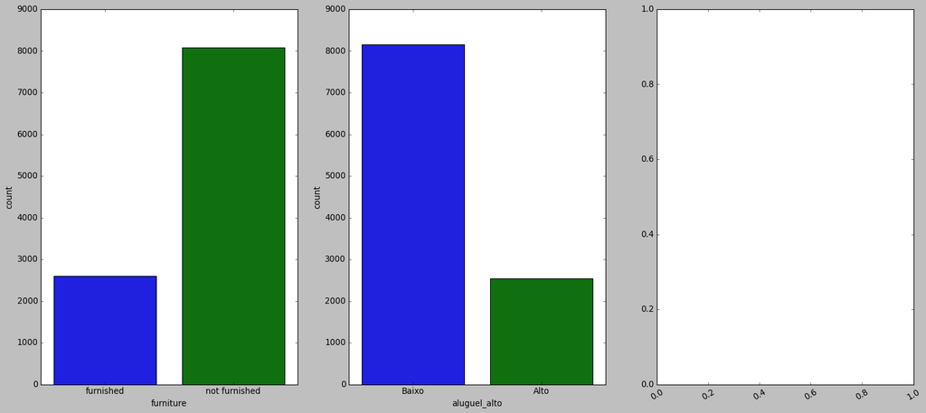

```python
plotObjCols(aux, numColsJuntas=3, tamanho=1.9)
```